# Renny_Oyelahan_Project_2

# Processing columns

```python
# turning Mileage, Engine and Power into numerics
'''
def Mileage_to_num(Mileage):
    """In the Mileage column I'm replacing the terminal 'km/kg' and kmpl with
    the empty string and converting to a float. Non-strings are
    np.nans and are kept as np.nans."""
    if isinstance(Mileage, str):
        return float(Mileage.replace('km/kg', ''))
    elif isinstance(Mileage, str):
        return float(Mileage.replace('kmpl', ''))
    elif isinstance(Mileage, float):
        return Mileage
    else:
        return np.nan
'''

def Mileage_to_num(Mileage):
    """In the Mileage column I'm replacing the terminal 'km/kg' and kmpl with
    the empty string and converting to a float. Non-strings are
    np.nans and are kept as np.nans."""
    if isinstance(Mileage, str):

        if 'km/kg' in Mileage:
            return float(Mileage.replace('km/kg', ''))
        elif 'kmpl' in Mileage:
            return float(Mileage.replace('kmpl', ''))

    elif isinstance(Mileage, float):
        return Mileage
    else:
        return np.nan


def Engine_to_num(Engine):
    """In the Engine column I'm replacing the terminal 'cc' with
    the empty string and converting to a float. Non-strings are
    np.nans and are kept as np.nans."""
    if isinstance(Engine, str):
        return float(Engine.replace('CC', ''))
    elif isinstance(Engine, float):
        return Engine
    else:
        return np.nan

def Power_to_num(Power):
    """In the Power column I'm replacing the terminal 'bhp' with
    the empty string and converting to a float. Non-strings are
    np.nans and are kept as np.nans."""
    if isinstance(Power, str):
        return float(Power.replace('bhp', ''))
    elif isinstance(Power, float):
        return Power
    else:
        return np.nan
```

```python
data['Power'] = data['Power'].apply(Power_to_num)
data['Power'].sample(n=20)
```

```
6377    187.74
1626    210.00
2090     67.04
1708    181.00
3120    118.00
1677     81.86
6608    170.00
2876    187.74
7054    450.00
242     100.60
5869     67.10
5178     58.33
5569    152.00
3389    187.74
1724    197.00
4007     86.80
6751     37.00
2386     70.00
407     270.90
3425     88.50
Name: Power, dtype: float64
```

```python
data['Engine'] = data['Engine'].apply(Engine_to_num)
data['Engine'].sample(n=20)
```

```
5883    1197.0
4901    1198.0
174     1968.0
4715    1248.0
1262    1968.0
4015    1995.0
4370     999.0
1214    1199.0
133      998.0
4446      72.0
1343    2354.0
5415    1197.0
1091    1197.0
6832    1797.0
660     2494.0
3885    1497.0
2558     799.0
5555    1197.0
2550    1248.0
3391    1197.0
Name: Engine, dtype: float64
```

```python
data['Mileage'] = data['Mileage'].apply(Mileage_to_num)
data['Mileage'].sample(n=20)
```

```
4786    20.00
1239    19.27
1268    17.11
4172    19.10
951     25.32
6487     9.74
5733    15.60
4372    22.54
6701    12.60
5573    19.67
151     22.90
3633    18.12
3996    16.07
4546    16.80
5411    12.70
1726    25.83
3137    13.00
807     18.60
7062    19.67
4224    14.00
Name: Mileage, dtype: float64
```

```python
data['Mileage'].head()
```

```
0    26.60
1    19.67
2    18.20
3    20.77
4    15.20
Name: Mileage, dtype: float64
```

```python
#Lets check to make sure Mileage, Engine and Power are now numerical values
data.info()
```

```
<class 'pandas.core.frame.DataFrame'>
RangeIndex: 7250 entries, 0 to 7249
Data columns (total 12 columns):
 #   Column             Non-Null Count  Dtype
---  ------             --------------  -----
 0   Name               7250 non-null   object
 1   Year               7250 non-null   int64
 2   Kilometers_Driven  7250 non-null   int64
 3   Fuel_Type          7250 non-null   object
 4   Transmission       7250 non-null   object
 5   Owner_Type         7250 non-null   object
 6   Mileage            7248 non-null   float64
 7   Engine             7204 non-null   float64
 8   Power              7075 non-null   float64
 9   Seats              7197 non-null   float64
 10  New_Price          7250 non-null   float64
 11  Price              6019 non-null   float64
dtypes: float64(6), int64(2), object(4)
memory usage: 679.8+ KB
```

## Let's visualize the data

### Univariate Analysis

```python
# function to plot a boxplot and a histogram along the same scale.


def histogram_boxplot(data, feature, figsize=(20, 10), kde=False, bins=None):
    """
    Boxplot and histogram combined

    data: dataframe
    feature: dataframe column
    figsize: size of figure (default (12,7))
    kde: whether to the show density curve (default False)
    bins: number of bins for histogram (default None)
    """
    f2, (ax_box2, ax_hist2) = plt.subplots(
        nrows=2,  # Number of rows of the subplot grid= 2
        sharex=True,  # x-axis will be shared among all subplots
        gridspec_kw={"height_ratios": (0.25, 0.75)},
        figsize=figsize,
    )  # creating the 2 subplots
    sns.boxplot(
        data=data, x=feature, ax=ax_box2, showmeans=True, color="violet"
    )  # boxplot will be created and a star will indicate the mean value of the column
    sns.histplot(
        data=data, x=feature, kde=kde, ax=ax_hist2, bins=bins, palette="winter"
    ) if bins else sns.histplot(
        data=data, x=feature, kde=kde, ax=ax_hist2
    )  # For histogram
    ax_hist2.axvline(
        data[feature].mean(), color="green", linestyle="--"
    )  # Add mean to the histogram
    ax_hist2.axvline(
        data[feature].median(), color="black", linestyle="-"
    )  # Add median to the histogram
```

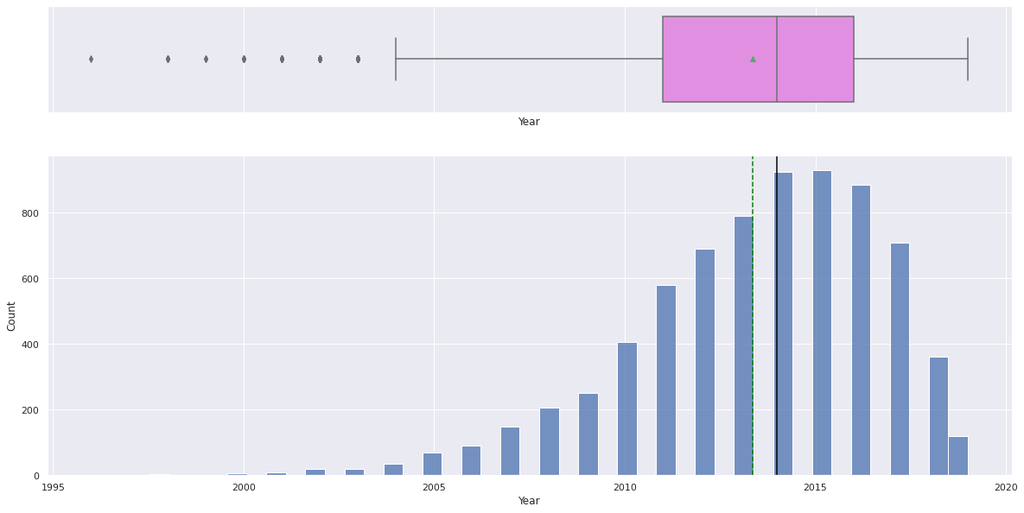

```python
histogram_boxplot(data, "Year")
```

Year is skewed to the left.

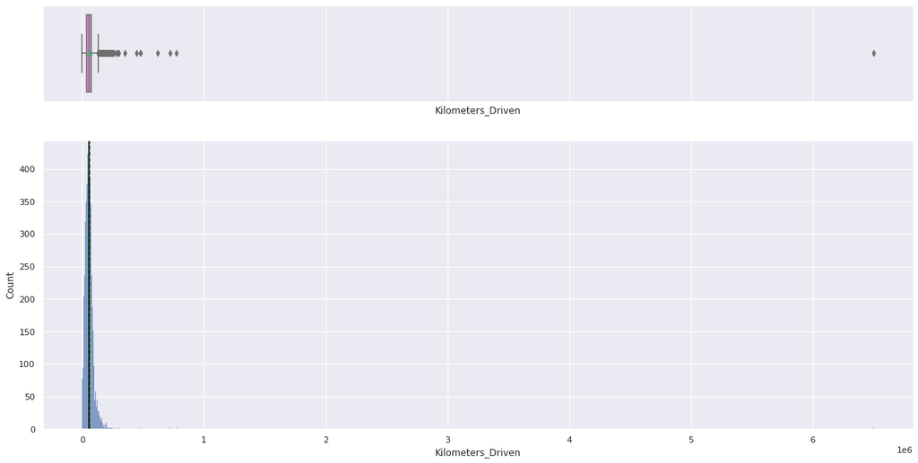

```python
histogram_boxplot(data, "Kilometers_Driven")
```

Kilometers driven is highly skewed to the right

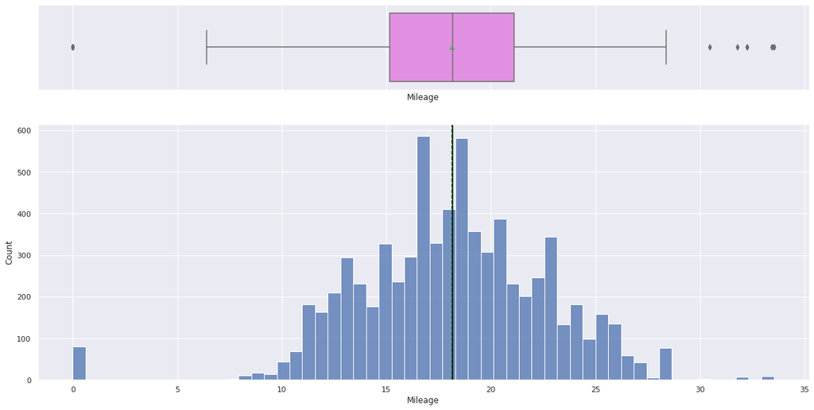

```python
histogram_boxplot(data, "Mileage")
```

Mileage has what appears to be normal distribution.

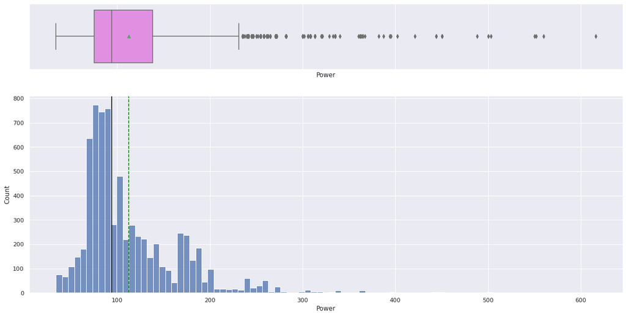

```python
histogram_boxplot(data, "Power")
```

Power is skewed to the right and has quite a number of outliers.

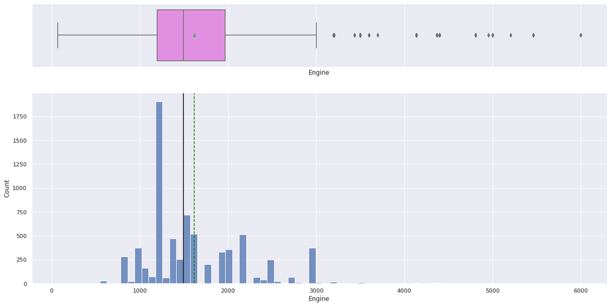

```python
histogram_boxplot(data, "Engine")
```

Engine is somewhat skewed to the right with outliers.

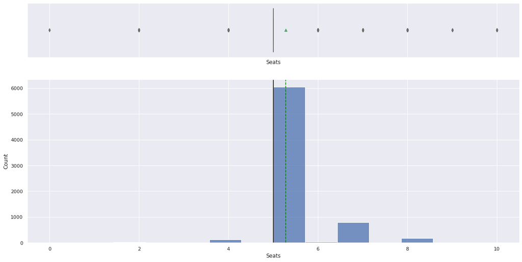

```python
histogram_boxplot(data, "Seats")
```

Majority of the used cars have 5 seats.

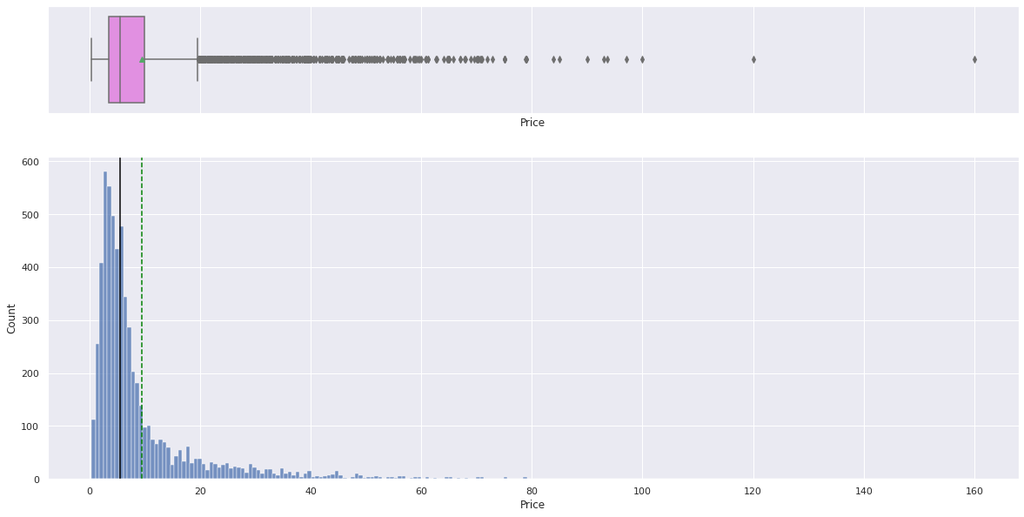

```python
histogram_boxplot(data, "Price")
```

Price is skewed to the right

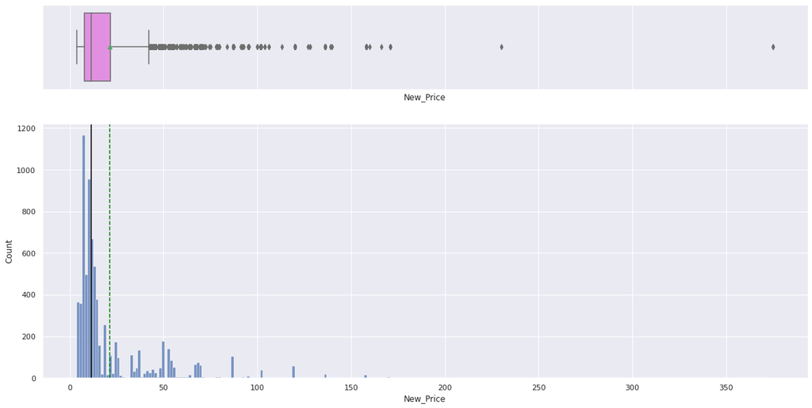

```python
histogram_boxplot(data, "New_Price")
```

Price of new car is also skewed to the right.

**Let's look at the non-numeric columns.**

```python
# filtering non-numeric columns
cat_columns = data.select_dtypes(exclude=np.number).columns
cat_columns
```

```
Index(['Name', 'Fuel_Type', 'Transmission', 'Owner_Type'], dtype='object')
```

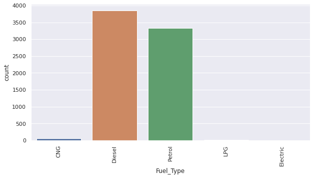

```python
plt.figure(figsize=(10, 5))
sns.countplot(data=data,x='Fuel_Type')
plt.xticks(rotation=90)
plt.show()
```

Diesel and Petrol are the most commonly used fuel types.

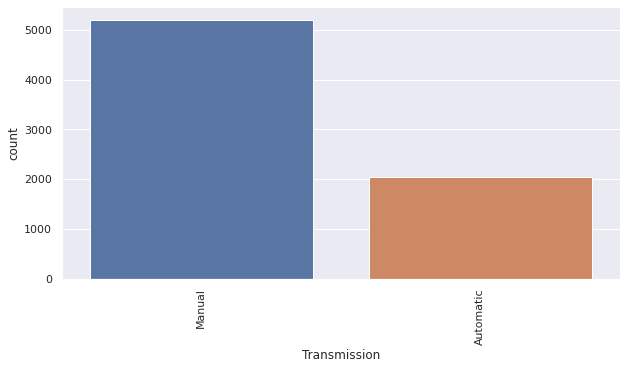

```python
plt.figure(figsize=(10, 5))
sns.countplot(data=data,x='Transmission')
plt.xticks(rotation=90)
plt.show()
```

There are a lot more manual transmission cars (more than double) than automatic transmission cars

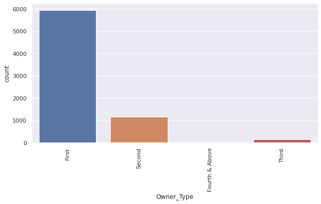

```python
plt.figure(figsize=(10, 5))
sns.countplot(data=data,x='Owner_Type')
plt.xticks(rotation=90)
plt.show()
```

The majority of people are first time owners.